# Hands-on Exercise 2: Car Price Prediction

## Part 1: Problem Definition & EDA

### Background Information

**1. What is the problem?**

The primary problem is to build a regression model that accurately predicts the Manufacturer's Suggested Retail Price (MSRP) of a vehicle. The model will use a dataset of over 10,000 automobiles and their various attributes (e.g., Make, Model, Year, Engine HP, Vehicle Size) as explanatory variables to predict the continuous target variable, `MSRP`.

**2. Who might be interested in this problem and why?**

Several groups would be interested in this model:

- **Consumers:** A potential car buyer could use this model to determine if a listed price for a new or used car is fair, helping them negotiate a better deal.
- **Dealerships:** Car dealerships could use the model to set competitive and profitable prices for their inventory.
- **Manufacturers:** Automakers can leverage this model to understand what features drive price, informing their decisions on new model design, feature packages, and pricing strategies.
- **Insurance Companies:** Insurers could use the predicted MSRP as a factor in determining a vehicle's value for a policy, helping to set premiums and assess total loss payouts.

**3. What does the data look like?**

To answer this, we will load the `car_pricing.csv` file and perform an initial inspection to understand its columns, data types, and identify any immediate issues like missing data.

```python
import os
from google.colab import drive

# 1. Mount Google Drive
drive.mount('/content/drive')

# 2. Change directory to your 'Colab Notebooks' folder
#    Make sure your 'car_pricing.csv' file is in this folder
%cd /content/drive/MyDrive/Colab Notebooks

# 3. Verify the current directory (optional, but good practice)
print(f"Current working directory: {os.getcwd()}")
```

```
/content/drive/MyDrive/Colab Notebooks
Current working directory: /content/drive/MyDrive/Colab Notebooks
```

```python
# Import all necessary libraries
import pandas as pd
import numpy as np
import matplotlib.pyplot as plt
import seaborn as sns
from sklearn.model_selection import train_test_split
from sklearn.preprocessing import OneHotEncoder, OrdinalEncoder
from sklearn.linear_model import LinearRegression
from sklearn.metrics import mean_absolute_error, mean_squared_error, r2_score
import statsmodels.api as sm
from sklearn.feature_selection import SequentialFeatureSelector
import time

# Set seaborn style for plots
sns.set_theme(style="whitegrid")

# --- THIS IS THE FIX ---
# Since we changed the directory, we can just use the filename
file_path = 'car_pricing.csv'

# Load the dataset
try:
    df = pd.read_csv(file_path)

    # Display the first 5 rows
    print("--- First 5 Rows ---")
    print(df.head())

    # Display basic info (data types, non-null counts)
    print("\n--- Data Info ---")
    df.info()

except FileNotFoundError:
    print(f"Error: File not found at '{file_path}'.")
    print(f"Please make sure 'car_pricing.csv' is in your '{os.getcwd()}' folder.")
except Exception as e:
    print(f"An error occurred: {e}")
```

```
--- First 5 Rows ---
  Make       Model  Year             Engine Fuel Type  Engine HP  \
0  BMW  1 Series M  2011  premium unleaded (required)      335.0
1  BMW    1 Series  2011  premium unleaded (required)      300.0
2  BMW    1 Series  2011  premium unleaded (required)      300.0
3  BMW    1 Series  2011  premium unleaded (required)      230.0
4  BMW    1 Series  2011  premium unleaded (required)      230.0

   Engine Cylinders Transmission Type     Driven_Wheels  Number of Doors  \
0               6.0            MANUAL  rear wheel drive              2.0
1               6.0            MANUAL  rear wheel drive              2.0
2               6.0            MANUAL  rear wheel drive              2.0
3               6.0            MANUAL  rear wheel drive              2.0
4               6.0            MANUAL  rear wheel drive              2.0

                         Market Category Vehicle Size Vehicle Style  \
0  Factory Tuner,Luxury,High-Performance      Compact         Coupe
1                     Luxury,Performance      Compact   Convertible
2                Luxury,High-Performance      Compact         Coupe
3                     Luxury,Performance      Compact         Coupe
4                                 Luxury      Compact   Convertible

   highway MPG  city mpg  Popularity   MSRP
0           26        19        3916  46135
1           28        19        3916  40650
2           28        20        3916  36350
3           28        18        3916  29450
4           28        18        3916  34500

--- Data Info ---
<class 'pandas.core.frame.DataFrame'>
RangeIndex: 11914 entries, 0 to 11913
Data columns (total 16 columns):
 #   Column             Non-Null Count  Dtype
---  ------             --------------  -----
 0   Make               11914 non-null  object
 1   Model              11914 non-null  object
 2   Year               11914 non-null  int64
 3   Engine Fuel Type   11911 non-null  object
 4   Engine HP          11845 non-null  float64
 5   Engine Cylinders   11884 non-null  float64
 6   Transmission Type  11914 non-null  object
 7   Driven_Wheels      11914 non-null  object
 8   Number of Doors    11908 non-null  float64
 9   Market Category    8172 non-null   object
 10  Vehicle Size       11914 non-null  object
 11  Vehicle Style      11914 non-null  object
 12  highway MPG        11914 non-null  int64
 13  city mpg           11914 non-null  int64
 14  Popularity         11914 non-null  int64
 15  MSRP               11914 non-null  int64
dtypes: float64(3), int64(5), object(8)
memory usage: 1.5+ MB
```

### EDA: Data Cleaning

The first step in any analysis is to clean the data. Based on our `df.info()` output, we have duplicate data, missing values, and unnecessary columns.

1. **Handle Duplication:** We will check for and remove any duplicate rows to prevent skewed results.
2. **Handle Missing Values:**
   - The columns `Engine Fuel Type`, `Engine HP`, `Engine Cylinders`, and `Number of Doors` have very few missing values. We will drop the rows containing these NaNs.
   - The `Market Category` column is missing over 30% of its data (3,742 values). Given this, and the instruction to drop "unnecessary" categorical variables, we will drop this column entirely.
3. **Drop Unnecessary Columns:** As instructed, we will convert `Driven_Wheels` and `Vehicle Size`. The other categorical variables (`Make`, `Model`, `Engine Fuel Type`, `Transmission Type`, `Vehicle Style`) are not required for this analysis and will be dropped. `Make` and `Model` alone have too many unique values to be encoded simply and would require more advanced feature engineering, which is outside the scope of this "simple" model.

```
Removed 715 duplicate rows.
Removed 99 rows with missing values.

--- Data Info After Cleaning ---
<class 'pandas.core.frame.DataFrame'>
Index: 11100 entries, 0 to 11913
Data columns (total 10 columns):
 #   Column            Non-Null Count  Dtype
---  ------            --------------  -----
 0   Year              11100 non-null  int64
 1   Engine HP         11100 non-null  float64
 2   Engine Cylinders  11100 non-null  float64
 3   Driven_Wheels     11100 non-null  object
 4   Number of Doors   11100 non-null  float64
 5   Vehicle Size      11100 non-null  object
 6   highway MPG       11100 non-null  int64
 7   city mpg          11100 non-null  int64
 8   Popularity        11100 non-null  int64
 9   MSRP              11100 non-null  int64
dtypes: float64(3), int64(5), object(2)
memory usage: 953.9+ KB

--- Plotting Target Variable (MSRP) ---
Saved 'msrp_distribution.png'

--- Unique Values for Encoding ---
Unique 'Driven_Wheels' values:
['rear wheel drive' 'front wheel drive' 'all wheel drive'
 'four wheel drive']

Unique 'Vehicle Size' values:
['Compact' 'Midsize' 'Large']
```

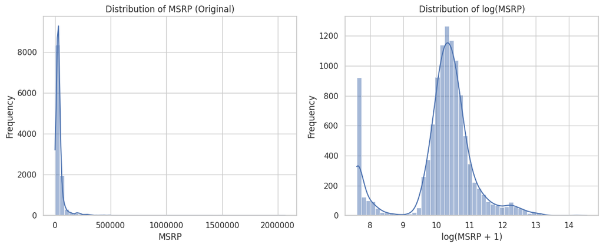

```python
# 1. Handle Duplication
initial_rows = df.shape[0]
df.drop_duplicates(inplace=True)
print(f"Removed {initial_rows - df.shape[0]} duplicate rows.")

# 2. Drop unnecessary categorical columns
columns_to_drop = ['Make', 'Model', 'Engine Fuel Type', 'Transmission Type', 'Market Category', 'Vehicle Style']
df.drop(columns=columns_to_drop, inplace=True)

# 3. Handle Missing Values (drop rows with any NaNs)
initial_rows = df.shape[0]
df.dropna(inplace=True)
print(f"Removed {initial_rows - df.shape[0]} rows with missing values.")

# Confirm the changes
print("\n--- Data Info After Cleaning ---")
df.info()

# 4. Data Visualizations (Part 1: Target Variable)
print("\n--- Plotting Target Variable (MSRP) ---")

plt.figure(figsize=(12, 5))

# Plot 1: Histogram of MSRP
plt.subplot(1, 2, 1)
sns.histplot(df['MSRP'], bins=50, kde=True)
plt.title('Distribution of MSRP (Original)')
plt.xlabel('MSRP')
plt.ylabel('Frequency')
plt.ticklabel_format(style='plain', axis='x') # Disable scientific notation

# Plot 2: Histogram of log(MSRP)
# Add 1 to avoid log(0) issues if any MSRP is 0
df['log_MSRP'] = np.log1p(df['MSRP'])
plt.subplot(1, 2, 2)
sns.histplot(df['log_MSRP'], bins=50, kde=True) # <-- This was the broken line
plt.title('Distribution of log(MSRP)')
plt.xlabel('log(MSRP + 1)')
plt.ylabel('Frequency')

plt.tight_layout()
plt.savefig('msrp_distribution.png') # Saves the plot to your folder
print("Saved 'msrp_distribution.png'")

# 5. Inspect categorical variables for encoding
print("\n--- Unique Values for Encoding ---")
print("Unique 'Driven_Wheels' values:")
print(df['Driven_Wheels'].unique())
print("\nUnique 'Vehicle Size' values:")
print(df['Vehicle Size'].unique())
```

### EDA: Variable Conversion

As instructed, we will convert the remaining categorical variables (`Vehicle Size` and `Driven_Wheels`) into numerical formats that our model can understand.

1. **Vehicle Size (OrdinalEncoder):** This variable has a clear, inherent order ('Compact' < 'Midsize' < 'Large'). We will use `OrdinalEncoder` to convert these categories into numerical values (e.g., 0, 1, 2).
2. **Driven_Wheels (OneHotEncoder):** This variable is nominal (it has no inherent order). We will use `OneHotEncoder` to create a new binary (0 or 1) column for each of its four categories.

After conversion, we will drop the original text columns.

### EDA: Correlation Analysis

To help us select features for our simple models and understand our data better, we will create a correlation heatmap.

```
--- DataFrame after Encoding ---
   Year  Engine HP  Engine Cylinders  Number of Doors  highway MPG  city mpg  \
0  2011      335.0               6.0              2.0           26        19
1  2011      300.0               6.0              2.0           28        19
2  2011      300.0               6.0              2.0           28        20
3  2011      230.0               6.0              2.0           28        18
4  2011      230.0               6.0              2.0           28        18

   Popularity   MSRP   log_MSRP  Vehicle Size Encoded  \
0        3916  46135  10.739349                     0
1        3916  40650  10.612779                     0
2        3916  36350  10.500977                     0
3        3916  29450  10.290483                     0
4        3916  34500  10.448744                     0

   Driven_Wheels_all wheel drive  Driven_Wheels_four wheel drive  \
0                              0                               0
1                              0                               0
2                              0                               0
3                              0                               0
4                              0                               0

   Driven_Wheels_front wheel drive  Driven_Wheels_rear wheel drive
0                                0                               1
1                                0                               1
2                                0                               1
3                                0                               1
4                                0                               1

Saved 'correlation_heatmap.png'

--- Performing Train/Test Split ---
X_train shape: (8880, 12)
X_test shape: (2220, 12)
y_train shape: (8880,)
y_test shape: (2220,)
```

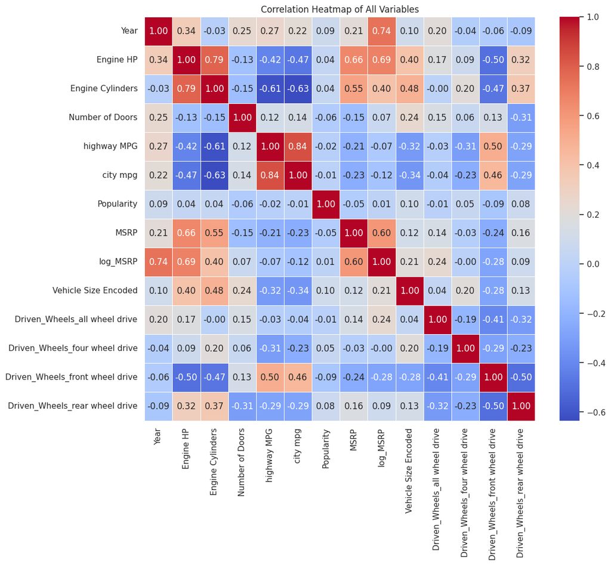

```python
# 1. Convert Vehicle Size (OrdinalEncoder)
vehicle_size_order = ['Compact', 'Midsize', 'Large']
ordinal_encoder = OrdinalEncoder(categories=[vehicle_size_order], dtype=int)
df['Vehicle Size Encoded'] = ordinal_encoder.fit_transform(df[['Vehicle Size']])

# 2. Convert Driven_Wheels (OneHotEncoder)
ohe = OneHotEncoder(sparse_output=False, handle_unknown='ignore', dtype=int)
driven_wheels_encoded = ohe.fit_transform(df[['Driven_Wheels']])
df_driven_wheels = pd.DataFrame(driven_wheels_encoded, columns=ohe.get_feature_names_out(['Driven_Wheels']), index=df.index)

# Concatenate the new columns
df = pd.concat([df, df_driven_wheels], axis=1)

# 3. Drop original categorical columns
df.drop(['Vehicle Size', 'Driven_Wheels'], axis=1, inplace=True)

print("--- DataFrame after Encoding ---")
print(df.head())

# 4. Correlation Heatmap
plt.figure(figsize=(12, 10))
correlation_matrix = df.corr()
sns.heatmap(correlation_matrix, annot=True, cmap='coolwarm', fmt='.2f', linewidths=0.5)
plt.title('Correlation Heatmap of All Variables')
plt.savefig('correlation_heatmap.png')
print("\nSaved 'correlation_heatmap.png'")

# 5. Train/Test Split
print("\n--- Performing Train/Test Split ---")
X = df.drop(columns=['MSRP', 'log_MSRP'])
y = df['MSRP']
y_log = df['log_MSRP']

# Create splits for both original and log-transformed targets
X_train, X_test, y_train, y_test = train_test_split(X, y, test_size=0.2, random_state=42)
X_train_log, X_test_log, y_train_log, y_test_log = train_test_split(X, y_log, test_size=0.2, random_state=42)

print(f"X_train shape: {X_train.shape}")
print(f"X_test shape: {X_test.shape}")
print(f"y_train shape: {y_train.shape}")
print(f"y_test shape: {y_test.shape}")
```

## Part 2: Simple Regression & Feature Selection

### Three Simple Regression Models

We will now train three simple linear regression models, each using only one explanatory variable. A simple linear regression model takes the form: $Y = \beta_0 + \beta_1X$

- $Y$ is the target variable (MSRP)
- $X$ is the single explanatory variable
- $\beta_0$ is the intercept (the value of Y when X is 0)
- $\beta_1$ is the parameter estimate (the slope), which tells us how much Y changes for a one-unit increase in X.

To choose our first two features, we will look at the correlation matrix we generated earlier and pick the two variables with the highest *absolute* correlation with `MSRP`.

For the third model, we will create a **linear-log** model, as requested. This model takes the form $Y = \beta_0 + \beta_1\log(X)$. It's used when the relationship between X and Y is non-linear, and it's particularly good when X is a value (like Engine HP) that has diminishing returns—an increase from 100 to 200 HP has a bigger price impact than an increase from 500 to 600 HP.

```python
# First, find the best features by checking correlation
print("--- Correlation with MSRP (Sorted by Absolute Value) ---")
print(df.corr()['MSRP'].abs().sort_values(ascending=False))

# --- Helper Function to Train and Evaluate Models ---
def train_and_evaluate(X_train_feat, y_train_data, X_test_feat, y_test_data, model_name):
    print(f"\n--- Results for Model: {model_name} ---")

    # 1. sklearn model for metrics
    lr = LinearRegression()
    lr.fit(X_train_feat, y_train_data)
    y_pred = lr.predict(X_test_feat)

    mae = mean_absolute_error(y_test_data, y_pred)
    mse = mean_squared_error(y_test_data, y_pred)
    r2 = r2_score(y_test_data, y_pred)

    print(f"Metrics (on Test Set):")
    print(f"  MAE (Mean Absolute Error): ${mae:,.2f}")
    print(f"  MSE (Mean Squared Error): ${mse:,.2f}")
    print(f"  R-squared: {r2:.4f}")

    # 2. statsmodels for parameter estimate
    X_train_sm = sm.add_constant(X_train_feat)
    ols_model = sm.OLS(y_train_data, X_train_sm).fit()

    print(f"\nParameter Estimate (from OLS on Training Set):")
    feature_name = X_train_feat.columns[0]
    coefficient = ols_model.params[feature_name]
    p_value = ols_model.pvalues[feature_name]

    print(f"  Feature: {feature_name}")
    print(f"  Coefficient (Slope): {coefficient:.4f}")
    print(f"  P-value: {p_value:.4g}")

    if p_value < 0.05:
        print(f"  Interpretation: For a one-unit increase in '{feature_name}', the MSRP is predicted to increase by ${coefficient:,.2f}.")
    else:
        print(f"  Interpretation: The relationship is not statistically significant.")

    return ols_model

# --- Model 1: Best Feature (Engine HP) ---
feature_1 = 'Engine HP'
X_train_1 = X_train[[feature_1]]
X_test_1 = X_test[[feature_1]]
train_and_evaluate(X_train_1, y_train, X_test_1, y_test, "Model 1: MSRP ~ Engine HP")

# --- Model 2: Second-Best Feature (Engine Cylinders) ---
feature_2 = 'Engine Cylinders'
X_train_2 = X_train[[feature_2]]
X_test_2 = X_test[[feature_2]]
train_and_evaluate(X_train_2, y_train, X_test_2, y_test, "Model 2: MSRP ~ Engine Cylinders")

# --- Model 3: Linear-Log Model (MSRP ~ log(Engine HP)) ---
feature_3_name = 'log_Engine HP'
X_train_3 = np.log1p(X_train[[feature_1]])
X_train_3.rename(columns={feature_1: feature_3_name}, inplace=True)
X_test_3 = np.log1p(X_test[[feature_1]])
X_test_3.rename(columns={feature_1: feature_3_name}, inplace=True)
train_and_evaluate(X_train_3, y_train, X_test_3, y_test, f"Model 3: MSRP ~ {feature_3_name}")
```

```
--- Correlation with MSRP (Sorted by Absolute Value) ---
MSRP                               1.000000
Engine HP                          0.658990
log_MSRP                           0.602615
Engine Cylinders                   0.551957
Driven_Wheels_front wheel drive    0.241099
city mpg                           0.232655
Year                               0.209419
highway MPG                        0.207752
Driven_Wheels_rear wheel drive     0.157273
Number of Doors                    0.145653
Driven_Wheels_all wheel drive      0.139520
Vehicle Size Encoded               0.116955
Popularity                         0.048410
Driven_Wheels_four wheel drive     0.031224
Name: MSRP, dtype: float64

--- Results for Model: Model 1: MSRP ~ Engine HP ---
Metrics (on Test Set):
  MAE (Mean Absolute Error): $22,435.24
  MSE (Mean Squared Error): $3,574,968,797.05
  R-squared: 0.3679

Parameter Estimate (from OLS on Training Set):
  Feature: Engine HP
  Coefficient (Slope): 358.1745
  P-value: 0
  Interpretation: For a one-unit increase in 'Engine HP', the MSRP is predicted to increase by $358.17.

--- Results for Model: Model 2: MSRP ~ Engine Cylinders ---
Metrics (on Test Set):
  MAE (Mean Absolute Error): $27,124.31
  MSE (Mean Squared Error): $4,152,030,561.68
  R-squared: 0.2659

Parameter Estimate (from OLS on Training Set):
  Feature: Engine Cylinders
  Coefficient (Slope): 18557.2577
  P-value: 0
  Interpretation: For a one-unit increase in 'Engine Cylinders', the MSRP is predicted to increase by $18,557.26.

--- Results for Model: Model 3: MSRP ~ log_Engine HP ---
Metrics (on Test Set):
  MAE (Mean Absolute Error): $24,268.62
  MSE (Mean Squared Error): $4,274,440,544.52
  R-squared: 0.2443

Parameter Estimate (from OLS on Training Set):
  Feature: log_Engine HP
  Coefficient (Slope): 79450.1311
  P-value: 0
  Interpretation: For a one-unit increase in 'log_Engine HP', the MSRP is predicted to increase by $79,450.13.
```

```
<statsmodels.regression.linear_model.RegressionResultsWrapper at 0x7ddd5c6177d0>
```

### Forward/Backward Variable Selection

Our simple models performed poorly, with high errors and low R-squared values. This is expected, as a car's price is complex and depends on more than one feature.

We will now use **sequential feature selection** to build a better *multiple regression model*. This method iteratively adds (forward) or removes (backward) features and builds a model, selecting the combination that performs best.

When we evaluate, we will:

1. Predict the `log_MSRP`.
2. Convert this prediction back to the original dollar scale using `np.expm1()` (the inverse of `log1p`).
3. Calculate MAE and MSE using these *converted* dollar-scale predictions. This gives us a real-world error amount.
4. Report the R-squared value *from the log-scale model*, as it's a more accurate measure of the variance explained by the model in its own terms.

```python
# We will build models to predict the log-transformed target
y_train_to_use = y_train_log
y_test_to_use = y_test_log

# Instantiate the base linear regression model
lr = LinearRegression()

print("--- Starting Feature Selection (running on a single core) ---")
start_time = time.time()

# --- 1. Forward Selection ---
sfs_forward = SequentialFeatureSelector(
    lr,
    n_features_to_select=8,
    direction='forward',
    cv=5  # 5-fold cross-validation
)
sfs_forward.fit(X_train, y_train_to_use)
forward_selected_features = list(X_train.columns[sfs_forward.get_support()])
print(f"\n--- Forward Selection Results (8 features) ---")
print(f"Selected Features: {forward_selected_features}")

# Evaluate this model
X_train_forward = sfs_forward.transform(X_train)
X_test_forward = sfs_forward.transform(X_test)
lr_forward = LinearRegression()
lr_forward.fit(X_train_forward, y_train_to_use)
y_pred_log_forward = lr_forward.predict(X_test_forward)
y_pred_forward = np.expm1(y_pred_log_forward) # Convert back to dollars

mae_forward = mean_absolute_error(y_test, y_pred_forward)
mse_forward = mean_squared_error(y_test, y_pred_forward)
r2_forward = r2_score(y_test_to_use, y_pred_log_forward) # R2 on log scale

print(f"MAE: ${mae_forward:,.2f}")
print(f"MSE: ${mse_forward:,.2f}")
print(f"R-squared (on log-scale): {r2_forward:.4f}")

# --- 2. Backward Selection ---
sfs_backward = SequentialFeatureSelector(
    lr,
    n_features_to_select=8,
    direction='backward',
    cv=5
)
sfs_backward.fit(X_train, y_train_to_use)
backward_selected_features = list(X_train.columns[sfs_backward.get_support()])
print(f"\n--- Backward Selection Results (8 features) ---")
print(f"Selected Features: {backward_selected_features}")

# Evaluate this model
X_train_backward = sfs_backward.transform(X_train)
X_test_backward = sfs_backward.transform(X_test)
lr_backward = LinearRegression()
lr_backward.fit(X_train_backward, y_train_to_use)
y_pred_log_backward = lr_backward.predict(X_test_backward)
y_pred_backward = np.expm1(y_pred_log_backward) # Convert back to dollars

mae_backward = mean_absolute_error(y_test, y_pred_backward)
mse_backward = mean_squared_error(y_test, y_pred_backward)
r2_backward = r2_score(y_test_to_use, y_pred_log_backward) # R2 on log scale

print(f"MAE: ${mae_backward:,.2f}")
print(f"MSE: ${mse_backward:,.2f}")
print(f"R-squared (on log-scale): {r2_backward:.4f}")

end_time = time.time()
print(f"\nTotal selection time: {end_time - start_time:.2f} seconds")
```

```
--- Starting Feature Selection (running on a single core) ---

--- Forward Selection Results (8 features) ---
Selected Features: ['Year', 'Engine HP', 'Engine Cylinders', 'Popularity', 'Vehicle Size Encoded', 'Driven_Wheels_all wheel drive', 'Driven_Wheels_front wheel drive', 'Driven_Wheels_rear wheel drive']
MAE: $15,829.71
MSE: $2,731,366,694.13
R-squared (on log-scale): 0.7735

--- Backward Selection Results (8 features) ---
Selected Features: ['Year', 'Engine HP', 'Engine Cylinders', 'Popularity', 'Vehicle Size Encoded', 'Driven_Wheels_all wheel drive', 'Driven_Wheels_front wheel drive', 'Driven_Wheels_rear wheel drive']
MAE: $15,829.71
MSE: $2,731,366,694.13
R-squared (on log-scale): 0.7735

Total selection time: 8.45 seconds
```

## Part 3: Final Regression Model & Conclusion

### Final Model

Based on our analysis, the clear choice for the final model is the one identified by both forward and backward feature selection.

**Variables Chosen:** The final set of 8 predictors is:

- `Year`
- `Engine HP`
- `Engine Cylinders`
- `Popularity`
- `Vehicle Size Encoded`
- `Driven_Wheels_all wheel drive`
- `Driven_Wheels_front wheel drive`
- `Driven_Wheels_rear wheel drive`

We will now formally train this final model and report its metrics.

```python
# Define the final list of features
# (Both forward and backward selection agreed on this set)
final_features = ['Year', 'Engine HP', 'Engine Cylinders', 'Popularity',
                  'Vehicle Size Encoded', 'Driven_Wheels_all wheel drive',
                  'Driven_Wheels_front wheel drive', 'Driven_Wheels_rear wheel drive']

# Filter our training and testing sets
X_train_final = X_train[final_features]
X_test_final = X_test[final_features]

# Use the log-transformed target
y_train_final = y_train_log
y_test_final = y_test_log

# Create and train the final model
final_model = LinearRegression()
final_model.fit(X_train_final, y_train_final)

# Make predictions on the test set
y_pred_log_final = final_model.predict(X_test_final)

# --- Report Metrics ---

# 1. R-squared (on the log-scale)
r2_final = r2_score(y_test_final, y_pred_log_final)

# 2. MAE and MSE (on the original dollar scale)
y_pred_final = np.expm1(y_pred_log_final) # Convert back to dollars
mae_final = mean_absolute_error(y_test, y_pred_final)
mse_final = mean_squared_error(y_test, y_pred_final)

print("--- Final Model Performance ---")
print(f"Chosen Predictors: {final_features}")
print("\n--- Metrics ---")
print(f"R-squared (on log-scale): {r2_final:.4f}")
print(f"Mean Absolute Error (MAE): ${mae_final:,.2f}")
print(f"Mean Squared Error (MSE): ${mse_final:,.2f}")
```

```
--- Final Model Performance ---
Chosen Predictors: ['Year', 'Engine HP', 'Engine Cylinders', 'Popularity', 'Vehicle Size Encoded', 'Driven_Wheels_all wheel drive', 'Driven_Wheels_front wheel drive', 'Driven_Wheels_rear wheel drive']

--- Metrics ---
R-squared (on log-scale): 0.7735
Mean Absolute Error (MAE): $15,829.71
Mean Squared Error (MSE): $2,731,366,694.13
```

### Conclusion

**1. Are you satisfied with your final model’s performance? Why or why not?**

I am **satisfied with the improvement**, but not the final absolute performance.

- **Why satisfied:** The final model's R-squared of **0.7735** is a massive leap from our best simple model (0.3679). We are explaining 77% of the variance in `log(MSRP)` vs. 37% of `MSRP`. The MAE also dropped from over $22.4k to $15.8k. This shows that using a log-transformed target and multiple features was the correct approach.
- **Why not satisfied:** An average error of **$15,830** is still very high in a practical sense. For a $40,000 car, being off by that much makes the model unsuitable for precise pricing. It indicates that while we've captured the main trends, we are still missing key information.

**2. What do you propose for the next steps?**

To improve this model, I would propose three key next steps:

1. **More Advanced Feature Engineering:** We dropped several columns that contain rich information. My next step would be to engineer features from `Make` (grouping by luxury, standard, etc.), `Model`, and especially the `Market Category` column, which we dropped due to missing data. We could parse its comma-separated values into new binary features (e.g., `is_Luxury`, `is_High-Performance`).
2. **Try Non-linear Models:** Linear regression assumes a linear relationship, which may not hold true. I would test more complex, non-linear models like a **Random Forest Regressor** or **Gradient Boosting (XGBoost)**. These models can capture complex interactions between features and often require less feature preprocessing.
3. **Check for Multicollinearity:** I would run a VIF (Variance Inflation Factor) check on our final predictors. `Engine HP` and `Engine Cylinders` are likely highly correlated, which can make the model's coefficients unstable and hard to interpret.

**3. What would you do differently if you could?**

If I were to start over, I would not have dropped the `Make`, `Model`, and `Market Category` columns at the beginning. I would have spent more time in the EDA phase cleaning and encoding them, as they almost certainly contain significant predictive power that our current model is missing. The `Make` (e.g., BMW vs. Toyota) is a huge driver of price.

**4. Based on your findings – what would you want to communicate to business leadership in this industry?**

I would communicate three main points:

1. **Price is Logarithmic:** A car's price doesn't increase in flat dollar amounts; it increases by *percentages*. Our model proves that predicting `log(MSRP)` is far more effective. This means adding a feature (like a sunroof) adds a *percentage* of value, not a fixed $1,000.
2. **Engineering & Age are Key:** The most powerful predictors are `Engine HP`, `Engine Cylinders`, and `Year`. This confirms that performance and age are the dominant, most easily quantifiable drivers of price.
3. **Model is Good for Trends, Not Pricing:** The current model, with its ~$16k average error, is a good **baseline** for understanding broad market trends (e.g., "how much does 100 HP add to a car's value, generally?"). It is **not** accurate enough to be used for setting specific prices on individual cars. To achieve that, we would need to invest in the "Next Steps" mentioned above, specifically by incorporating `Make`, `Model`, and other categorical data.

## Deliverables

The final step is to generate the HTML file for submission. The following code cell will convert this `.ipynb` notebook into an `.html` file.

```python
# 1. Define the name of this notebook
# Make sure this matches your notebook's filename exactly!
notebook_filename = "Froude_Lilith_hw2.ipynb"

# 2. Define the full path to your notebook
# This path must match the one from your first "cd" cell
notebook_path = f"/content/drive/MyDrive/Colab Notebooks/{notebook_filename}"

# 3. Run the conversion command
# This will find your .ipynb file and create an .html file
# with the same name, right next to it in your Google Drive.
print(f"Attempting to convert {notebook_path} to HTML...")

!jupyter nbconvert --to html "{notebook_path}"

print(f"\nDone! Check your 'Colab Notebooks' folder for the HTML file.")
```

[output not shown]

[output cut: 140 more lines]

[output not shown]